# Technology and Social Change

Lecture 14: AI and International Relations

Bogdan G. Popescu

bgpopescu@tec.mx

Tecnológico de Monterrey

# Objectives

## Learning Objectives

By the end of this lecture, students should be able to:

1. **Apply IR theories** (Realism, Liberalism, Constructivism) to AI
2. **Explain the geopolitical logic** of US-China AI competition
3. **Assess AI’s military and cyber implications** (autonomous weapons, state cyber operations)
4. **Understand why AI infrastructure is power** (chips, energy, data centers)
5. **Compare AI governance models** (democratic vs. authoritarian) and their distributional consequences

# AI and IR Theory

## What Are IR Theories?

International Relations (IR) theories are **frameworks for explaining how states behave** in world politics.

Each theory makes different assumptions about:

- **Actors**: Who matters? (states, firms, individuals, ideas)
- **Motivations**: What do they want? (security, wealth, status)
- **Structure**: What shapes their behavior? (anarchy, institutions, norms)

The three dominant paradigms — **Realism**, **Liberalism**, and **Constructivism** — offer competing lenses for understanding the same events.

## Realism: Power and Anarchy

**Core claim**: The international system is **anarchic** — no world government exists above states.

**Key assumptions**:

- States are the central actors
- States seek **security and power** to survive
- Cooperation is fragile; conflict is recurrent

**Classical thinkers**: Thucydides, Hobbes, Morgenthau, Waltz, Mearsheimer.

**Signature concept**: The *security dilemma* — one state’s defensive moves look offensive to others, triggering arms races.

## Liberalism: Cooperation and Institutions

**Core claim**: States can **cooperate** through trade, institutions, and shared interests — anarchy is not destiny.

**Key assumptions**:

- States *and* firms, NGOs, and individuals matter
- Economic interdependence reduces conflict
- International institutions (UN, WTO, treaties) shape behavior

**Classical thinkers**: Kant, Locke, Keohane, Nye, Ikenberry.

**Signature concept**: *Complex interdependence* — multiple channels of contact between societies make war costly and cooperation rational.

## Constructivism: Ideas and Norms

**Core claim**: World politics is shaped not just by material power, but by **shared ideas, identities, and norms**.

**Key assumptions**:

- Interests are *constructed*, not given
- Norms (e.g., against chemical weapons) constrain states
- Identity (“ally”, “rogue state”, “superpower”) shapes behavior

**Classical thinkers**: Wendt, Finnemore, Sikkink, Katzenstein.

**Signature concept**: *“Anarchy is what states make of it”* (Wendt, 1992, *International Organization* 46(2): 391–425, at p. 395) — the same structure can produce competition or community depending on shared understandings.

## AI and IR Theory: Three Paradigms

**Note**

“We anticipate more cross-theoretical debates… given the different sets of axioms each theory brings.” — Ndzendze & Marwala (2023, ch. 10, p. 157)

**Realism**: States seek power in an anarchic system — AI as strategic asset

**Liberalism**: States cooperate through trade and institutions — AI enables shared governance

**Constructivism**: Ideas and norms shape world politics — AI reshapes threat perceptions, identities, and the meaning of “AI superpower”

## Why These Theories Matter for AI

Each theory points to a different causal mechanism — and predicts a different empirical signature:

| Theory | Mechanism (why) | What we’d expect to see |
| --- | --- | --- |
| **Realism** | Anarchy forces states to compete for power | US chip export controls; China’s domestic AI acceleration |
| **Liberalism** | Interdependence and institutions reward cooperation | UN AI resolutions; US–China nuclear-AI pledge (Nov 2024) |
| **Constructivism** | Identities and norms define what counts as a threat | “AI superpower” framing; campaigns to ban autonomous weapons |

*We start with the US-China rivalry, where **Realism** does the most explanatory work.*

# The US-China AI Competition

## US-China AI Competition: Both Sides Are Racing

**Realist prediction**: states fearing relative loss invest heavily in strategic technology.

**United States**

- **$500B Stargate Project (2025)** — venture to build AI data centres
- **CHIPS and Science Act ($52.7B)** — law subsidising US semiconductor manufacturing
- **Export controls on advanced chips** — bars Nvidia’s top AI chips from sale to China

**China**

- **Files far more AI patents than the US (2019–2025)**
- **DeepSeek R1 triggered a 3.1% Nasdaq drop** — cheap Chinese reasoning model (Jan 2025)
- **295,000 industrial robots installed (2024)** — more than the rest of the world combined

## US-China AI Competition: Both Sides Are Racing

**Realist prediction**: states fearing relative loss invest heavily in strategic technology.

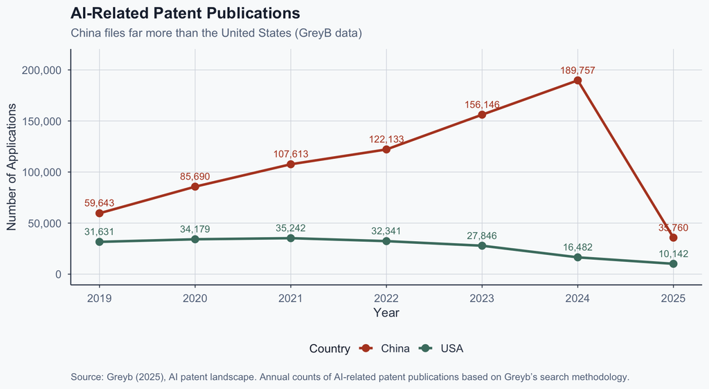

Source: GreyB Patent Database (2019–2025)

AI patent filings, 2019-2025. Source: GreyB

## Parity Is Real — and That Makes the Rivalry Rational

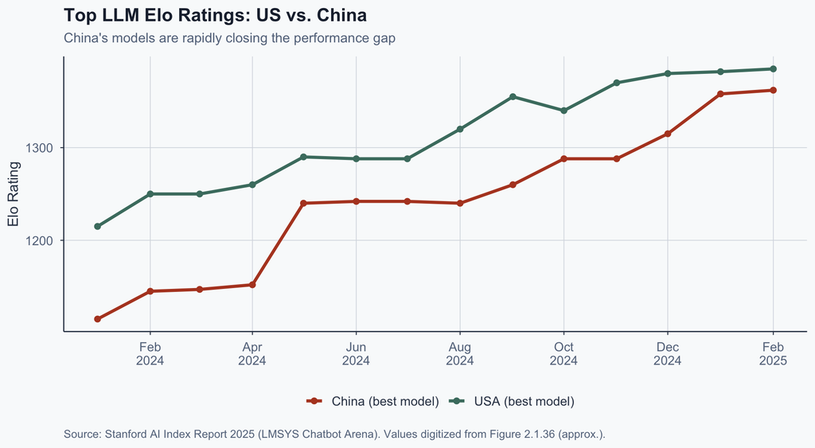

**Implication**: the gap is narrow enough that each side could plausibly overtake the other — the precondition for a security dilemma.

## Security Dilemma in AI Competition

```
%%{init: {'theme': 'base', 'themeVariables': {'fontSize': '18px', 'primaryColor': '#4a7c6f', 'primaryTextColor': '#1e293b', 'lineColor': '#334155', 'secondaryColor': '#f9fafb'}, 'flowchart': {'useMaxWidth': true, 'nodeSpacing': 40, 'rankSpacing': 45, 'curve': 'basis'}, 'width': 1150, 'height': 650}}…
flowchart LR
    A["US invests<br/>in AI"] --> B["China perceives<br/>threat"]
    B --> C["China increases<br/>AI investment"]
    C --> D["US perceives<br/>China catching up"]
    D --> E["US increases<br/>controls<br/>(chip bans)"]
    E --> F["China accelerates<br/>domestic<br/>development"]
    F --> B

    style A fill:#4a7c6f,color:#f9fafb,stroke:#334155
    style B fill:#b44527,color:#f9fafb,stroke:#334155
    style C fill:#b44527,color:#f9fafb,stroke:#334155
    style D fill:#4a7c6f,color:#f9fafb,stroke:#334155
    style E fill:#4a7c6f,color:#f9fafb,stroke:#334155
    style F fill:#b44527,color:#f9fafb,stroke:#334155
```

**Key insight**: Anarchy creates competition regardless of intentions (Realist mechanism)

## The “Digital Cold War”

*What the security dilemma produces at the system level: blocs, fragile rules, decoupling.*

**Note**

“As of mid-2025, the geopolitics of AI stands at a crossroads… the world could slide further into fragmentation, with a digital iron curtain separating US-led and China-led tech spheres.” — World Economic Forum, *AI geopolitics and data in the era of technological rivalry* (24 July 2025). [weforum.org/stories/2025/07/ai-geopolitics-data-centres-technological-rivalry](https://www.weforum.org/stories/2025/07/ai-geopolitics-data-centres-technological-rivalry/)

## The “Digital Cold War”

*What the security dilemma produces at the system level: blocs, fragile rules, decoupling.*

**1. Bloc Formation** — Chip 4 Alliance (US, Japan, Taiwan, South Korea) vs. Digital Silk Road

**2. Liberal moment** — Nov 2024: US–China pledge that humans, not AI, should control nuclear weapons. *Even rivals find some cooperation rational.*

**3. Strategic Decoupling** — April 2025: US banned Nvidia H20 chip exports to China

## Exercise 1: Applying IR Theories

**Class Discussion (5 min)** — *The Nvidia chip ban (April 2025)*

Is the US ban on Nvidia H20 chip exports to China a sign of American **strength** or of American **weakness**?

Bring in any IR theory that helps your argument — and what it means for **Mexico’s** chip supply-chain role (Sonora plant, nearshoring).

# AI and Military Applications

## From Competition to the Battlefield

If AI is a core arena of great-power rivalry, its most dangerous application is **military force**.

- AI is increasingly used in targeting and weapons systems
- This raises legal and ethical questions about killing by machines

One of the central debates is over **Lethal Autonomous Weapons Systems (LAWS)**.

[figure not shown]

An MQ-9 Reaper unmanned aerial vehicle — one of the most widely deployed military drones. Source: Wikimedia Commons (public domain, US Air Force).

## Lethal Autonomous Weapons Systems (LAWS)

[video not shown]

Source: https://www.youtube.com/watch?v=X7MqE-vqnSw

1. How does the video define autonomous weapon systems?  
2. In which regions are autonomous weapons already being used?  
3. What does “automation bias” mean, and why is it dangerous?  
4. What international response is discussed in the video?

## LAWS: Definitions and Regulation

**Note**

CCW working characterization (Chair’s rolling text, 8 November 2024): “An integrated combination of weapons and technological components that enable the system to identify and/or select, and engage a target, without intervention by a human user.”

Source: GGE on LAWS, Chair’s summary, UN doc CCW/GGE.1/2025/WP.1, 7 April 2025, p. 3, Box I, para. 1.

*UN General Assembly resolution on LAWS (Dec 2024), of 193 member states:*

- **166** in favor of negotiating regulation
- **3** opposed (Russia, DPRK, Belarus)
- **15** abstained
- **2026** target for binding treaty

[figure not shown]

The UN General Assembly Hall, where 166 nations voted in favor of autonomous weapons regulation. Source: Wikimedia Commons (public domain).

## Why LAWS Regulation Fails

```
%%{init: {'theme': 'base', 'themeVariables': {'fontSize': '18px', 'primaryColor': '#b44527', 'primaryTextColor': '#1e293b', 'lineColor': '#334155', 'secondaryColor': '#f9fafb'}, 'flowchart': {'useMaxWidth': true, 'nodeSpacing': 40, 'rankSpacing': 50, 'curve': 'basis'}, 'width': 1150, 'height': 650}}…
flowchart LR
    A["All states want<br/>to avoid an<br/>arms race"] --> B["Each state fears<br/>disadvantage if<br/>others develop LAWS"]
    B --> C["Verification is<br/>nearly impossible<br/>(software, not hardware)"]
    C --> D["Defection is the<br/>dominant strategy"]
    D --> E["Result: 166 UN votes<br/>in favor, but<br/>no binding treaty"]

    style A fill:#4a7c6f,color:#f9fafb,stroke:#334155
    style B fill:#b7943a,color:#1e293b,stroke:#334155
    style C fill:#b7943a,color:#1e293b,stroke:#334155
    style D fill:#b44527,color:#f9fafb,stroke:#334155
    style E fill:#b44527,color:#f9fafb,stroke:#334155
```

**Key insight**: Unlike nuclear weapons (visible, countable), AI is embedded in software — verification is structurally difficult.

## From Autonomous Weapons to Cyber Warfare

LAWS represents one dimension of AI’s military impact. AI is also transforming **cyberspace**.

- AI doesn’t just power weapons — it enables new forms of attack
- Cyber operations are now a primary tool of great-power competition

The ODNI’s 2025 Annual Threat Assessment identifies China as “the most active and persistent cyber threat to U.S. government, private-sector, and critical infrastructure networks.”

Source: ODNI, *Annual Threat Assessment of the U.S. Intelligence Community* (March 2025), p. 11.

## State-Level Cyber Operations: The Dual-Use Problem

AI is dual-use: the same capabilities empower **state attackers** and **state defenders**.

**Offensive (state actors):**

- Adaptive malware that evades detection
- Automated reconnaissance and vulnerability discovery
- AI-generated influence operations (deepfakes, scaled disinformation)

**Defensive (governments, critical infrastructure):**

- Predictive threat intelligence
- Automated incident response and attribution

## Volt Typhoon: Inside a State Cyber Operation

[video not shown]

Source: https://www.youtube.com/watch?v=xaGZbMUIjjs

1. What is Volt Typhoon, and what does the video say its purpose is — espionage, theft, or something else?  
2. Which sectors of US critical infrastructure does the video identify as targets?  
3. What does CISA mean by “prepositioning for disruption”, and how does it differ from ordinary hacking?  
4. How does the video link Volt Typhoon to a potential crisis over Taiwan?

## Exercise 2: Autonomous Weapons Debate

**Small Group Debate (7 min)** — *Should LAWS be banned outright, or regulated?*

- **Group A — BAN**: machines should never decide to kill; verification failures mean any use sets a dangerous precedent.
- **Group B — REGULATE**: a total ban is unenforceable; require human oversight (“human-in-the-loop”) instead.

Each group: **3 min to argue, 1 min to rebut**.

# AI Infrastructure

## Semiconductor Wars: The Critical Chokepoint

**Export Controls as Weapon**

- Jan 15, 2025: BIS issued a proposed “AI Diffusion” export-control framework (global licensing tiers for advanced AI chips)
- May 13, 2025: BIS rescinded the AI Diffusion rule before implementation (export controls still exist, but not under that specific framework)

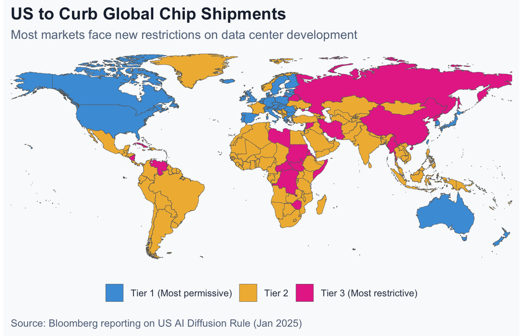

## Semiconductor Manufacturing Shift

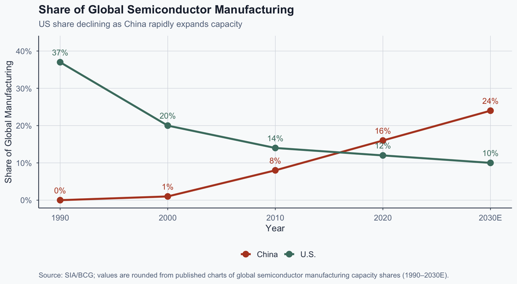

Source: Semiconductor Industry Association (SIA)

## How Chip Chokepoints Create Leverage

```
%%{init: {'theme': 'base', 'themeVariables': {'fontSize': '17px', 'primaryColor': '#4a7c6f', 'primaryTextColor': '#1e293b', 'lineColor': '#334155', 'secondaryColor': '#f9fafb'}, 'flowchart': {'useMaxWidth': true, 'nodeSpacing': 30, 'rankSpacing': 40, 'curve': 'basis'}, 'width': 1150, 'height': 650}}…
flowchart LR
    A["Chip Design<br/>(US dominance)<br/>Nvidia, AMD"] --> D["CHOKEPOINT<br/>Any node can<br/>be weaponized"]
    B["Chip Fabrication<br/>(Taiwan dominance)<br/>TSMC: 92% of advanced nodes"] --> D
    C["Chip Equipment<br/>(Netherlands)<br/>ASML: 100% EUV"] --> D
    D --> E["US export<br/>controls"]
    D --> F["Taiwan<br/>invasion risk"]
    D --> G["ASML restricted<br/>from China sales"]

    style A fill:#4a7c6f,color:#f9fafb,stroke:#334155
    style B fill:#b7943a,color:#1e293b,stroke:#334155
    style C fill:#b44527,color:#f9fafb,stroke:#334155
    style D fill:#1e293b,color:#f9fafb,stroke:#334155
    style E fill:#64748b,color:#f9fafb,stroke:#334155
    style F fill:#64748b,color:#f9fafb,stroke:#334155
    style G fill:#64748b,color:#f9fafb,stroke:#334155
```

**Key insight**: Unlike oil, chips cannot be stockpiled — technology ages. Control is ongoing.

## Data Center Energy vs. Countries

*The “electron gap”: China builds AI infrastructure faster than democracies — fewer permitting hurdles, less public opposition.*

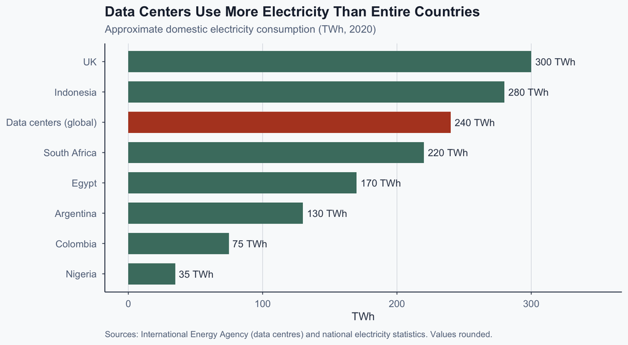

Source: Enerdata, IEA (2020 data)

# Big Tech as a Transnational Actor

## Big Tech as a Transnational Actor

A handful of firms — Nvidia, Microsoft, Google, OpenAI, Meta, Anthropic, ByteDance — now control the AI stack:

- **Compute** (data centers, cloud)
- **Chips** (accelerators, supply chains)
- **Data + distribution** (platforms, defaults)

**IR implication**:

- Power doesn’t flow only through states
- Firms negotiate directly with governments
- They set de-facto rules and operate across borders
- A Liberal/Constructivist point — complicates state-centric Realism

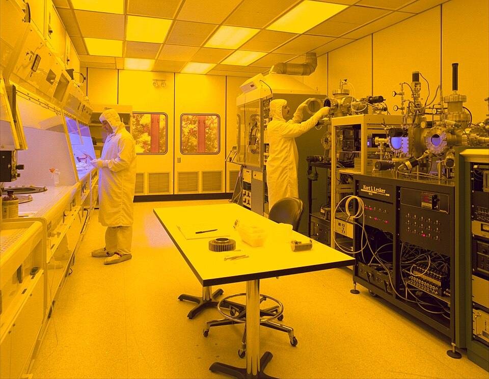

A semiconductor clean room at NASA Glenn Research Center. Advanced chip fabrication requires extreme precision and massive capital investment — creating natural chokepoints in the AI supply chain. Source: NASA / Wikimedia Commons (public domain).

# Democracy vs. Authoritarianism

## Deepfakes and the Liar’s Dividend

[video not shown]

Source: https://www.youtube.com/watch?v=JZl3cQTL6U0

1. What “additional harm” do AI deepfakes add to ordinary disinformation, according to Citron?  
2. What is the *liar’s dividend* (Citron & Chesney, 2019), and why is it dangerous?  
3. How could a well-timed deepfake affect an election?  
4. What tradeoffs does Citron identify with using law to regulate political deepfakes?

## Two Visions of AI Governance

**Democratic Model (US/EU)**

- Innovation with guardrails
- Market-driven development
- Concentration of power in Big Tech
- Growth vs. worker protections tension

**Authoritarian Model (China)**

- State licensing: AI must align with state
- Strategic infrastructure approach
- Rapid deployment, no public opposition

**Critical questions**: Who controls training data? Who sets safety standards? Who benefits?

Sources: Euronews (2025); AI Now Institute (2025)

## AI and the Global South: Risk of Backsliding

**Boix et al. (2026)**: AI may reverse decades of North–South economic convergence.

- Automation + reshoring make low-wage labor advantages **obsolete**
- AI can replace previously offshored services: customer support, software, accounting, translation

**Political consequence**: Mexican communities exposed to foreign robots shift **leftward** — a different coalition structure than the right-wing populism advanced economies see.

**Bottom line**: If AI traps industrializing countries in middle-income status, democratic institutions weaken and authoritarian alternatives become more tempting.

Source: Boix et al. (2026), Section 6. World Bank: ~1.8B jobs in developing countries are potentially automatable.

# Conclusion

## Key Takeaways

- **Great-power competition**: AI reshapes security, influence, and status — with US–China at the core
- **Military and cyber dimensions** intensify ethical-legal dilemmas — from autonomous weapons to state cyber prepositioning
- **Physical infrastructure is geopolitical power** — chips, data centers, and electricity as chokepoints
- **Power is not only state power**: Big Tech firms shape AI governance as transnational actors
- **Governance models diverge** — democratic vs. authoritarian — with distributional consequences for the Global South

## Analytical Framework

Use these concepts to structure your analysis:

| Concept | Application |
| --- | --- |
| **Security dilemma** | Why states arms-race even when all prefer not to (US–China AI) |
| **Collective action** | Why treaties fail despite shared interests (LAWS regulation) |
| **Chokepoints** | Where leverage exists in supply chains (chips, energy) |
| **Prepositioning** | Why cyber access placed *now* is leverage *later* (Volt Typhoon) |
| **Liar’s dividend** | Why real evidence can be dismissed in a deepfake era |
| **Distributional conflict** | Who gains, who loses, and how this shapes politics (Global South) |

## References

- Boix, C., Becher, M., González-Rostani, V., & Stegmueller, D. (2026). AI’s economy and its political and institutional consequences. APSA Task Force on AI and Political Science.
- Acemoglu, D., & Johnson, S. (2023). *Power and Progress*. PublicAffairs.
- Brynjolfsson, E., & McAfee, A. (2014). *The Second Machine Age*. W. W. Norton.
- Frey, C. B. (2019). *The Technology Trap*. Princeton UP.
- Goldin, C., & Katz, L. F. (2008). *The Race between Education and Technology*. Harvard UP.
- GreyB. (2025). AI patent landscape report.
- Mandiant / Google Cloud. (2024). M-Trends 2024: Special report.
- Masanet, E., et al. (2020). Recalibrating global data center energy-use estimates. *Science*, 367(6481), 984–986.
- Ndzendze, B., & Marwala, T. (2023). *Artificial Intelligence and International Relations Theories*. Palgrave Macmillan.
- ODNI. (2025). *Annual Threat Assessment of the U.S. Intelligence Community*.
- SIA/BCG. (2024). Emerging resilience in the semiconductor supply chain.
- Stanford HAI. (2025). *AI Index Report 2025*.
- Statista Market Insights. (2025). Estimated cost of cybercrime worldwide.
- World Economic Forum. (2025). AI geopolitics and data in the era of technological rivalry.